# Single Cell Analysis Workshop

Jonathan Ronen

Vedran Franke

19 February 2018

# 1 Intro

Through this tutorial you should get familiar with the structure of the SingleCellExperiment object, and basic functions for manipulation, and quality control of the single cell expression data.

## 1.1 Single Cell Experiment Object

SingleCellExperiment object is a container for single cell data. It is build upon the SummarizedExperiment object, with the following structure

[figure not shown]

SingleCellExperiment

## 1.2 The Data

For this workshop we will use the publicly available data set, provided by 10x genomics. The count matrix can be found on the following link: [link](https://s3-us-west-2.amazonaws.com/10x.files/samples/cell/pbmc3k/pbmc3k_filtered_gene_bc_matrices.tar.gz).

We have pre-processed the data into a hdf5 file. **hdf5** file format is constructed for fast manipulation with array based data types (i.e. matrices). It stores indexed location for fast random access. You can consider the hdf5 file like a 2d bam file.

## 1.3 Preliminaries:

If you haven’t installed the required R packages, please install them now:

```r
source("https://bioconductor.org/biocLite.R")

biocLite(c("data.table","DelayedArray","DelayedMatrixStats","dplyr","GenomicAlignments","GenomicFiles","GenomicRanges","HDF5Array","pheatmap","Rsamtools","rtracklayer","scater","scran","SingleCellExperiment","stringr","yaml", "devtools"))

devtools::install_github("csoneson/iSEE", ref='3.4')

devtools::install_github("bimsbbioinfo/netSmooth", ref='bioconductor_3_6')
```

In addition, please install the following packages:

ggplot2, biomaRt, cowplot, ComplexHeatmap, dplyr

```r
source("https://bioconductor.org/biocLite.R")

biocLite(c('ggplot2','biomaRt','cowplot','ComplexHeatmap','dplyr'))
```

# 2 Exercises

### 2.0.1 Constructing SingleCellExperiment Objects

From the files in the data folder construct the SingleCellExperiment object. Hint: h5ls, HDF5Array, SingleCellExperiment

First you will need to connect to the hdf5 object. Then you will pass the object to the SingleCellExperiment constructor.

To connect to the hdf5 file, you will need the name of the saved matrix. This information can be obtained using the h5ls function

```r
suppressPackageStartupMessages(library(HDF5Array))
input_hdf5 = 's10x_3cells.hdf5'
name = h5ls(input_hdf5)$name

mat = HDF5Array(file=input_hdf5, name=name)

suppressPackageStartupMessages(library(SingleCellExperiment))
sce = SingleCellExperiment(
     assays  = list(counts=mat))
```

### 2.0.2 What is the size of the constructed single cell experient?

```r
print(object.size(sce),units='Mb')
```

```
## 0.1 Mb
```

### 2.0.3 What do the following functions do?

assays

rowData

colData

### 2.0.4 Add the gene names, and biotypes to the SingleCellExperiment object

The table **genes.tsv** contains ENSEMBL gene ids for the corresponding rows of the expression matrix. Load the table into R.

Using the biomaRt package, download the gene names and gene biotypes for the genes in the SingleCellExperiment object, and update the gene annotations. Hint: useMart, getBM, rowData

```r
gene_names = read.table('genes.tsv')

library(biomaRt)
mart = useMart(biomart = "ensembl", dataset = "hsapiens_gene_ensembl")
bm   = getBM(mart       = mart,
             attributes = c('ensembl_gene_id','hgnc_symbol','gene_biotype'),
             filters    = 'ensembl_gene_id',
             values     = gene_names$V1)

bm = bm[match(gene_names$V1, bm$ensembl_gene_id),]

rowData(sce) = DataFrame(bm)


head(rowData(sce))
```

```
## DataFrame with 6 rows and 3 columns
##   ensembl_gene_id hgnc_symbol   gene_biotype
##       <character> <character>    <character>
## 1 ENSG00000243485 MIR1302-2HG        lincRNA
## 2 ENSG00000237613     FAM138A        lincRNA
## 3 ENSG00000186092       OR4F5 protein_coding
## 4 ENSG00000238009                    lincRNA
## 5 ENSG00000239945                    lincRNA
## 6              NA          NA             NA
```

### 2.0.5 Remove all genes which could not be annotated in the previous step

Remove all rows with NA values.

```r
sce = sce[!is.na(rowData(sce)$ensembl_gene_id)]
```

# 3 SingleCellExperiment Exploration

In this step we will learn how to extract the basic information from the SingleCellExperiment object. For this we will use function from the DelayedMatrixStats package. DelayedMatrixStats package

### 3.0.1 How many lincRNAs are analyzed in the data?

```r
sum(rowData(sce)$gene_biotype == 'lincRNA')
```

```
## [1] 6645
```

### 3.0.2 Remove all genes which have less than 100 reads in all cells

Hint: DelayedMatrixStats package

```r
suppressPackageStartupMessages(library(DelayedMatrixStats))
rs = DelayedMatrixStats::rowSums2(assays(sce)$counts)
sce = sce[rs > 100,]
```

### 3.0.3 What is the number of expressed genes per cell?

First count the number of 0 values, per cell. Hint: DelayedMatrixStats::colCounts

```r
zero = DelayedMatrixStats::colCounts(assays(sce)$counts, value=0)

dropout = round(zero/nrow(sce),2)
```

Add the dropout rate to the column descriptors of the SingleCellExperiment object.

```r
colData(sce)$dropout = dropout

head(colData(sce))
```

```
## DataFrame with 6 rows and 1 column
##     dropout
##   <numeric>
## 1      0.86
## 2      0.77
## 3      0.80
## 4      0.83
## 5      0.91
## 6      0.86
```

Now plot a histogram of dropout values.

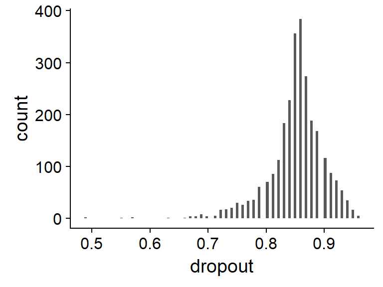

```r
suppressPackageStartupMessages(library(dplyr))
suppressPackageStartupMessages(library(ggplot2))

as.data.frame(colData(sce)) %>%
    ggplot(aes(dropout)) +
    geom_histogram(bins=100)
```

### 3.0.4 Plot the dropout rate Vs average expression

Now plot the dropout rate Vs the average expression of expressed genes, per cell.

```r
csum   = DelayedMatrixStats::colSums2(assays(sce)$counts)
ngenes = nrow(sce) - zero
colData(sce)$total_counts = csum
colData(sce)$mean_expr    = round(csum/ngenes, 2)
```

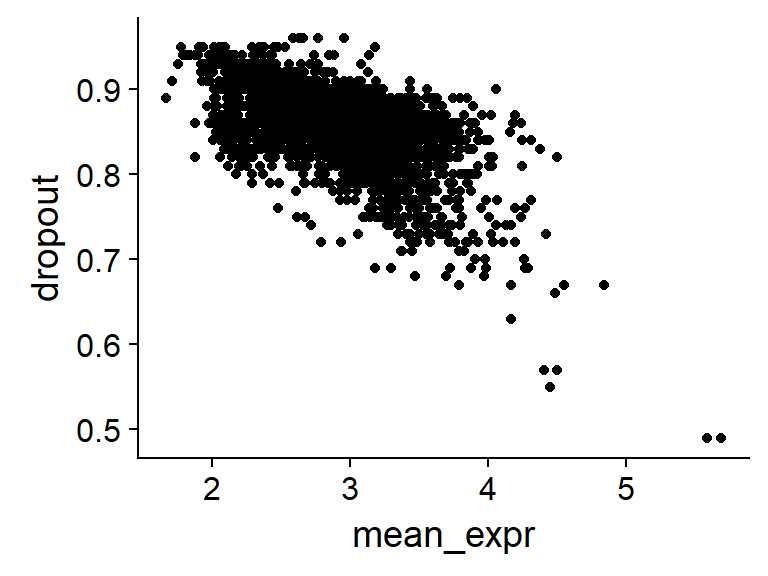

```r
as.data.frame(colData(sce)) %>%
    ggplot(aes(x=mean_expr, y=dropout)) +
    geom_point()
```

### 3.0.5 Adding size factors

Append the total number of reads per cell as size factors to the SingleCellExperiment object.

```r
sizeFactors(sce) = colData(sce)$total_counts
head(sizeFactors(sce))
```

```
## [1] 2294 4665 3013 2521  904 2062
```

### 3.0.6 Normalize the data

Take a look at the normalizeSCE function from the scater package. Use the function to normalize the expression data.

```r
suppressPackageStartupMessages(library(scater))
sce = normalizeSCE(sce,
                 exprs_values        = 'counts',
                 return_log          = TRUE,
                 log_exprs_offset    = 1,
                 centre_size_factors = FALSE)
```

### 3.0.7 Can you plot the distribution of average expression for protein coding genes, and lincRNAs?

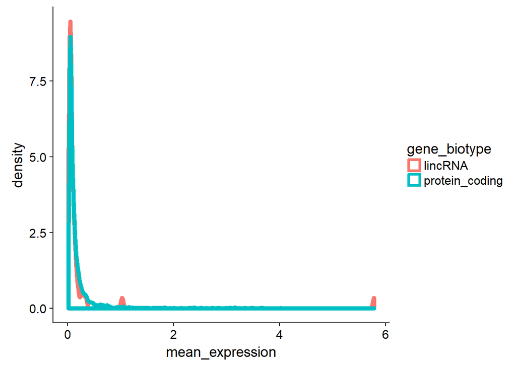

```r
rowData(sce)$mean_expression = DelayedMatrixStats::rowMeans2(assays(sce)$logcounts)
as.data.frame(rowData(sce)) %>%
    dplyr::filter(gene_biotype %in% c('protein_coding','lincRNA')) %>%
    ggplot(aes(mean_expression, color=gene_biotype)) +
    geom_density(size=2)
```

## 3.1 Scale the data

Create a function which will scale the normalized expression values. Scaling is defined as subtracting the mean, and dividing by the standard deviation. This operation is useful for making relative comparisons between genes, and visualizing differences between gene expression.

```r
scaleDM = function(dm) {
  #subtract column means from corresponding columns
  cdm = t(dm - DelayedMatrixStats::rowMeans2(dm)) #centred delayed matrix
  #scale
  scdm = t(cdm / DelayedMatrixStats::rowSds(cdm)) #scaled centered delayed matrix
  return(scdm)
}

assays(sce)$scale = scaleDM(assays(sce)$logcounts)
```

## 3.2 Find the cell cycle markers

```r
cc.pairs = readRDS(system.file("exdata", paste0("human_cycle_markers.rds"), package="scran"))
```

Using the cyclone function calculate the cell cycle phase for each gene. Add the results to the colData of the SingleCellExperiment object. Cells that did not end with an assigned cell cycle phase mark as unknown.

```r
assigned = scran::cyclone(x = sce,
                          gene.names = rowData(sce)$ensembl_gene_id,
                          assay.type = 'logcounts',
                          pairs      = cc.pairs)

phases = assigned$phases
phases[is.na(phases)] = 'unknown'
colData(sce) = cbind(colData(sce), DataFrame("CellCyclePhase" = phases))
```

# 4 Dimensinallity Reduction

In this section you will learn how to use the dimensionallity reduction methods on the SingleCell experiment objects.

## 4.1 PCA

Using the runPCA function from the scater package, calculate the first 5 principle components for the data.

Where does the function store the principle components? How can you access them?

```r
sce = scater::runPCA(object         = sce,
                     ncomponents    = 5,
                     pca_data_input = 'logcounts')
```

Using the plotPCA function, overlay the cell cycle phase on the scatterplot of PC1 Vs PC2.

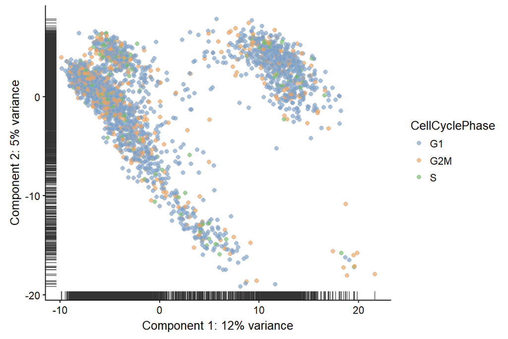

```r
scater::plotPCA(object         = sce,
                colour_by      = 'CellCyclePhase',
                pca_data_input = 'logcounts')
```

Now plot the first principal component Vs 2nd to 5th principal component, and color the plots by the dropout rate

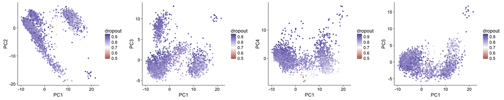

```r
dat = as.data.frame(colData(sce)) %>%
    cbind(as.data.frame(reducedDims(sce)$PCA))
gl = lapply(2:5, function(x){
    dat %>%
    ggplot(aes_string('PC1',paste0('PC',x), color='dropout')) +
        geom_point() +
        scale_color_gradient2(midpoint=0.7)
})

suppressPackageStartupMessages(library(cowplot))
plot_grid(plotlist = gl, nrow=1)
```

Repeat the same figure, but with the cell cycle phase.

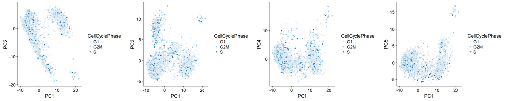

```r
dat = as.data.frame(colData(sce)) %>%
    cbind(as.data.frame(reducedDims(sce)$PCA))
gl = lapply(2:5, function(x){
    dat %>%
    ggplot(aes_string('PC1',paste0('PC',x), color='CellCyclePhase')) +
        geom_point() +
        scale_color_brewer()
})

suppressPackageStartupMessages(library(cowplot))
plot_grid(plotlist = gl, nrow=1)
```

## 4.2 tSNE

Using the functions from the scater package calculate the tSNE for the SingleCellExperiment object.

```r
sce = scater::runTSNE(object      = sce,
                      ncomponents = 2,
                      use_dimred  = 'PCA')
```

Plot the tSNE colored by the cell cycle phase.

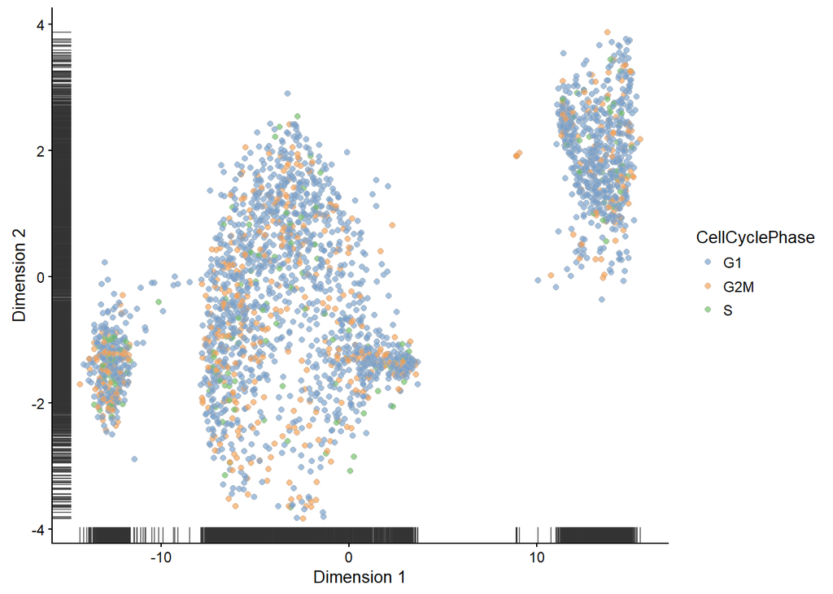

```r
scater::plotTSNE(object    = sce,
                 colour_by = 'CellCyclePhase')
```

# 5 Gene Exploration

### 5.0.1 Finding highly variable genes

In this section you will use variance decomposition methods to extract genes whoose biological variance is higher than the technical variance - i.e. to extract differentially expressed genes.

Append the resulting table to the rowData object.

Hint: normalize, trendVar, decomposeVar

```r
sce    = normalize(sce)
fit    = scran::trendVar(x = sce, assay.type = 'logcounts', use.spikes = FALSE)
decomp = scran::decomposeVar(x = sce, fit = fit, assay.type = 'logcounts')
rowData(sce) = cbind(rowData(sce),
                      DataFrame(decomp))

head(rowData(sce))
```

```
## DataFrame with 6 rows and 10 columns
##   ensembl_gene_id hgnc_symbol   gene_biotype mean_expression       mean
##       <character> <character>    <character>       <numeric>  <numeric>
## 1 ENSG00000188976       NOC2L protein_coding      0.09839118 0.09839118
## 2 ENSG00000188290        HES4 protein_coding      0.05386238 0.05386238
## 3 ENSG00000187608       ISG15 protein_coding      0.69715632 0.69715632
## 4 ENSG00000186891    TNFRSF18 protein_coding      0.03666522 0.03666522
## 5 ENSG00000186827     TNFRSF4 protein_coding      0.06493849 0.06493849
## 6 ENSG00000078808        SDF4 protein_coding      0.13266927 0.13266927
##        total          bio       tech      p.value          FDR
##    <numeric>    <numeric>  <numeric>    <numeric>    <numeric>
## 1 0.10465728 -0.003365731 0.10802301 8.744331e-01 1.000000e+00
## 2 0.05757126 -0.001563885 0.05913514 8.342535e-01 1.000000e+00
## 3 0.83486788  0.264362900 0.57050498 8.678130e-51 4.223638e-49
## 4 0.04279255  0.002538057 0.04025449 1.135585e-02 6.221515e-02
## 5 0.07875970  0.007464177 0.07129553 9.635087e-05 7.970411e-04
## 6 0.13494933 -0.008294283 0.14324361 9.846327e-01 1.000000e+00
```

### 5.0.2 Plot the mean - variance plot

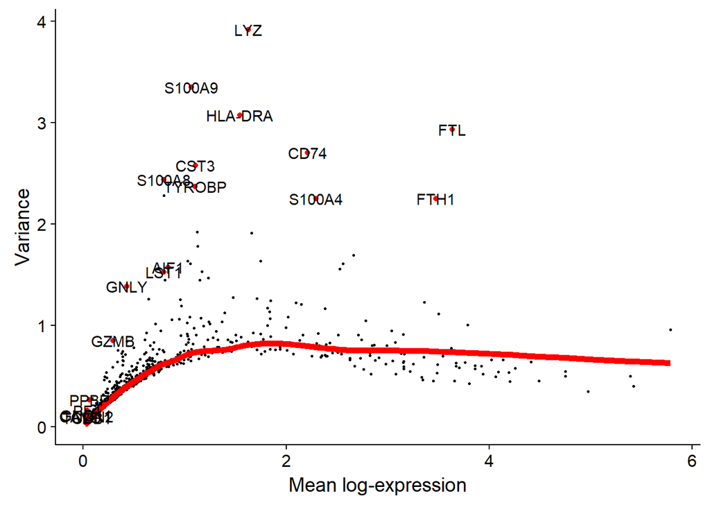

```r
data = as.data.frame(rowData(sce))
top_genes = data  %>%
    dplyr::arrange(FDR) %>%
    head(20)

data %>%
    ggplot(aes(mean, total)) +
    geom_point(size=.5) +
    geom_line(data = data, aes(mean, tech), color='red', size=2) +
    xlab('Mean log-expression') +
    ylab('Variance') +
    geom_point(data = top_genes, aes(mean, total), color='red') +
    geom_text(data = top_genes, aes(label = hgnc_symbol))
```

### 5.0.3 Gene expression heatmap

Plot top 50 genes that contribute to principle component 1. For this you will need the contribution of each gene to each principle component (gene loadings).

First, run the prcomp function to extract, and extract the gene loadings.

```r
results = stats::prcomp(x = assays(sce)$scale,
                       center = FALSE,
                       scale. = FALSE,
                       rank   = 2)

rowData(sce) = cbind(rowData(sce), DataFrame(results$x))
```

Now select the top 50 genes with the highest gene loadings to PC1, and plot a heatmap of their scaled expression values. (if you don’t have scaled expression values, go to **Scale the data**)

Hint: ComplexHeatmap::Heatmap

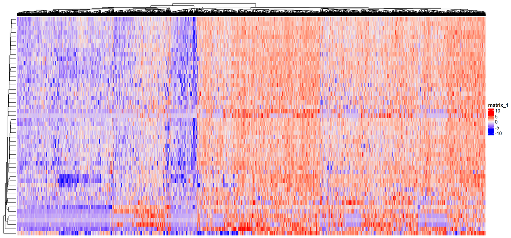

```r
top_genes = as.data.frame(rowData(sce)) %>%
    dplyr::arrange(-PC1) %>%
    head(50)

sce_sub = sce[rowData(sce)$ensembl_gene_id %in% top_genes$ensembl_gene_id,]

suppressPackageStartupMessages(library(ComplexHeatmap))
dat = data.frame(as.matrix(assays(sce_sub)$scale))
rownames(dat) = rowData(sce)$hgnc_name
Heatmap(dat, show_row_names = FALSE, show_column_names = FALSE)
```

## 5.1 Gene expression on tSNE

Find the top 4 genes with highest biological variance, and overlay their expression on the tSNE. Arrange the plots in a rectangle. Hint: cowplot::plot_grid

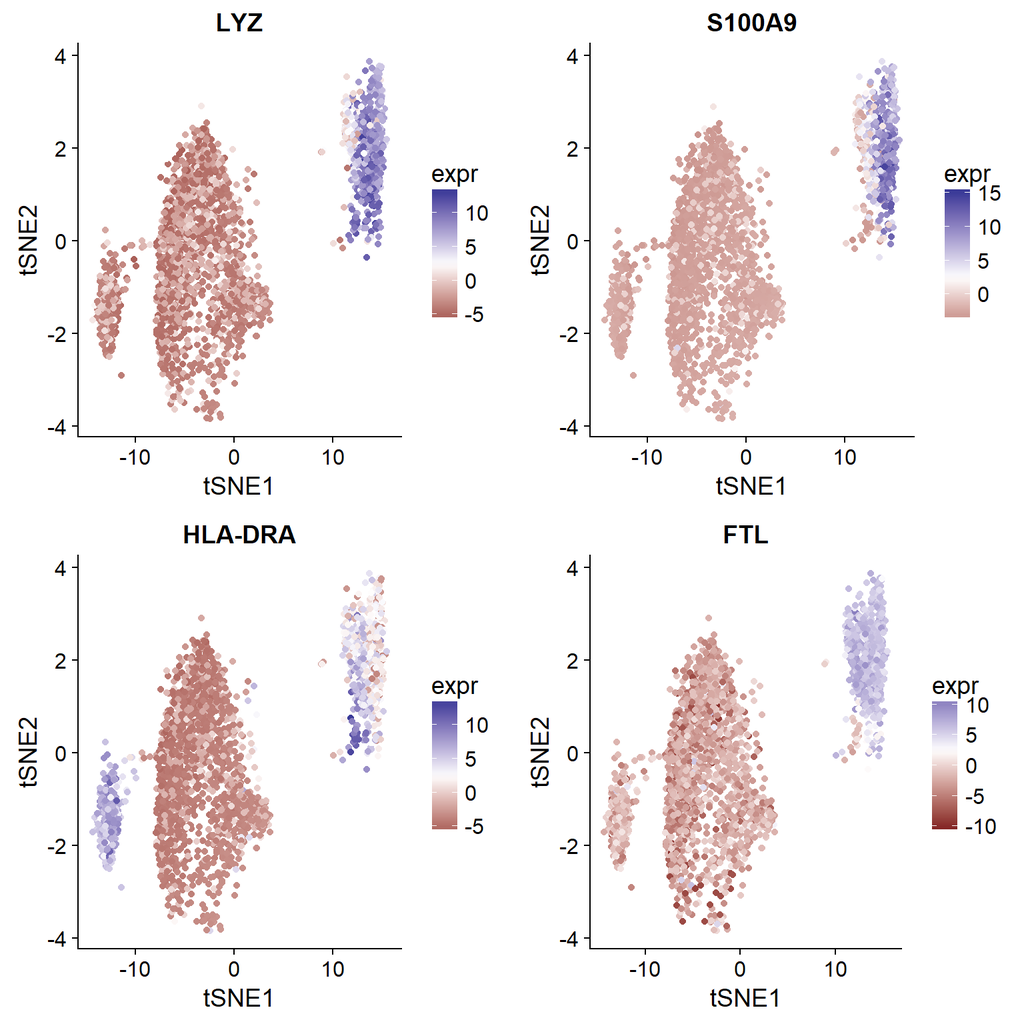

```r
dat = as.data.frame(colData(sce)) %>%
    cbind(as.data.frame(reducedDims(sce)$TSNE)) %>%
    dplyr::rename(tSNE1 = V1) %>%
    dplyr::rename(tSNE2 = V2)

genes = as.data.frame(rowData(sce)) %>%
    dplyr::arrange(-bio)

gl = lapply(1:4, function(i){
    ind = rowData(sce)$ensembl_gene_id == genes$ensembl_gene_id[i]
    dat %>%
        dplyr::mutate(expr = assays(sce)$scale[ind,]) %>%
        ggplot(aes(tSNE1, tSNE2, color=expr)) +
        geom_point() +
        scale_color_gradient2(midpoint=2.5) +
        ggtitle(genes$hgnc_symbol[i])
})
library(cowplot)
plot_grid(plotlist=gl)
```

# 6 Clustering

**scran** package contains two functions for clustering of the single cell data. Explore the quickCluster function. What types of cluterings does it provide?

Execute the provided clustering altgorithms, and overlay the results on the tSNE.

```r
colData(sce)$cluster = scran::quickCluster(sce,
                     min.size   = 1,
                     method     = 'igraph',
                     assay.type = 'logcounts',
                     pc.approx  = TRUE,
                     d          = 150,
                     rand.seed  = 1)
```

```r
colData(sce)$cluster_hier = scran::quickCluster(sce,
                     min.size   = 10,
                     method     = 'hclust',
                     assay.type = 'logcounts')
```

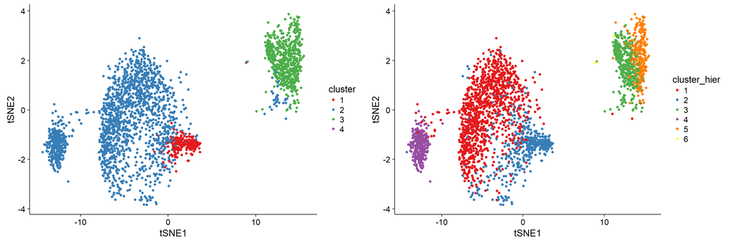

```r
g1 = as.data.frame(colData(sce)) %>%
    cbind(as.data.frame(reducedDims(sce)$TSNE)) %>%
    dplyr::rename(tSNE1 = V1) %>%
    dplyr::rename(tSNE2 = V2) %>%
    ggplot(aes(tSNE1, tSNE2, color=cluster)) +
    geom_point() +
    scale_color_brewer(palette='Set1')


g2 = as.data.frame(colData(sce)) %>%
    cbind(as.data.frame(reducedDims(sce)$TSNE)) %>%
    dplyr::rename(tSNE1 = V1) %>%
    dplyr::rename(tSNE2 = V2) %>%
    ggplot(aes(tSNE1, tSNE2, color=cluster_hier)) +
    geom_point() +
    scale_color_brewer(palette='Set1')

plot_grid(g1, g2)
```

### 6.0.1 Consensus based clustering

Bioconductor provides many additional clustering methods which can be used for the analysis of single cell data: ClusterExperiment, SC3 …

If you lasted until here, install the SC3 package from Bioconductor, and try the clustering algorithm on the dataset. Overlay the results on the tSNE.

This is still in development, so try to overcome the errors.

```r
library(SC3)
rowData(sce)$feature_symbol = rowData(sce)$hgnc_symbol
sce_mat = sce
assays(sce_mat) = lapply(assays(sce_mat), as.matrix)
sc = sc3(sce_mat, ks = 6, biology=FALSE, rand_seed=1)
```

```r
as.data.frame(colData(sc)) %>%
    cbind(as.data.frame(reducedDims(sc)$TSNE)) %>%
    dplyr::rename(tSNE1 = V1) %>%
    dplyr::rename(tSNE2 = V2) %>%
    ggplot(aes(tSNE1, tSNE2, color = sc3_5_clusters)) +
    geom_point() +
    scale_color_brewer(palette='Set1')
```

# 7 Interactive exploration of the SingleCellExperiment object

## 7.1 Interactive exploration using **iSEE**

Now you will use the iSEE package for active exploration of the single cell data. iSEE constructs a shiny app from the SingleCellExperiment object, which can then be run using the shiny::runApp function

```r
library(iSEE)
app = iSEE(sce)
shiny::runApp(app)
```

# 8 Extras

### 8.0.1 Saving and loading SingleCellExperiment Objects

```r
library(DelayedArray)
saveHDF5SummarizedExperiment(sce, dir = './sce')
```

```r
sce_h5 = loadHDF5SummarizedExperiment("./sce/")
sce_h5
```

### 8.0.2 QC metrics

```r
qc = calculateQCMetrics(sce)
```

### 8.0.3 Dimensionallity reduction using **Zinbwave**

Zinbwave is a new method for modeling single cell data. Zinbwave can be used for dimensionality reduction, dropout modelling, and differential expression.

For example:

This will take a while

```r
library(zinbwave)
zinb = zinbFit(sce_mat, K=2, epsilon=1000)

W = getW(zinb)
colnames(W) = paste0("W", 1:2)

data.frame(W, bio=colData(sce_mat)$cluster,
           dropout=colData(sce_mat)$dropout) %>%
    ggplot(aes(W1, W2, colour=bio)) +
    geom_point() +
    scale_color_brewer(type = "qual", palette = "Set1") +
    theme_classic()
```

# 9 References

[Summarized Experiment](https://bioconductor.org/packages/release/bioc/html/SummarizedExperiment.html)

[Single Cell Experiment](https://bioconductor.org/packages/release/bioc/html/SingleCellExperiment.html)

[scater](https://bioconductor.org/packages/release/bioc/html/scater.html)

[scran](https://bioconductor.org/packages/release/bioc/html/scran.html)

[biomaRt](https://bioconductor.org/packages/release/bioc/html/biomaRt.html)

[biomaRt](https://bioconductor.org/packages/release/bioc/html/ComplexHeatmap.html)

[DelayedMatrixStats](https://bioconductor.org/packages/release/bioc/html/DelayedMatrixStats.html)

[Bioconductor single cell expression tutorial](http://bioconductor.org/help/workflows/simpleSingleCell/)

[Zinbwave](https://bioconductor.org/packages/release/bioc/vignettes/zinbwave/inst/doc/intro.html#zinb-wave)

[List of tools for single cell analysis](https://github.com/seandavi/awesome-single-cell)